# Analysis of Red Wine by Travis Hinton

This report explores the quality of wine.

# Univariate Plots Section

```
##        X          fixed.acidity   volatile.acidity  citric.acid
##  Min.   :   1.0   Min.   : 4.60   Min.   :0.1200   Min.   :0.000
##  1st Qu.: 400.5   1st Qu.: 7.10   1st Qu.:0.3900   1st Qu.:0.090
##  Median : 800.0   Median : 7.90   Median :0.5200   Median :0.260
##  Mean   : 800.0   Mean   : 8.32   Mean   :0.5278   Mean   :0.271
##  3rd Qu.:1199.5   3rd Qu.: 9.20   3rd Qu.:0.6400   3rd Qu.:0.420
##  Max.   :1599.0   Max.   :15.90   Max.   :1.5800   Max.   :1.000
##  residual.sugar     chlorides       free.sulfur.dioxide
##  Min.   : 0.900   Min.   :0.01200   Min.   : 1.00
##  1st Qu.: 1.900   1st Qu.:0.07000   1st Qu.: 7.00
##  Median : 2.200   Median :0.07900   Median :14.00
##  Mean   : 2.539   Mean   :0.08747   Mean   :15.87
##  3rd Qu.: 2.600   3rd Qu.:0.09000   3rd Qu.:21.00
##  Max.   :15.500   Max.   :0.61100   Max.   :72.00
##  total.sulfur.dioxide    density             pH          sulphates
##  Min.   :  6.00       Min.   :0.9901   Min.   :2.740   Min.   :0.3300
##  1st Qu.: 22.00       1st Qu.:0.9956   1st Qu.:3.210   1st Qu.:0.5500
##  Median : 38.00       Median :0.9968   Median :3.310   Median :0.6200
##  Mean   : 46.47       Mean   :0.9967   Mean   :3.311   Mean   :0.6581
##  3rd Qu.: 62.00       3rd Qu.:0.9978   3rd Qu.:3.400   3rd Qu.:0.7300
##  Max.   :289.00       Max.   :1.0037   Max.   :4.010   Max.   :2.0000
##     alcohol         quality
##  Min.   : 8.40   Min.   :3.000
##  1st Qu.: 9.50   1st Qu.:5.000
##  Median :10.20   Median :6.000
##  Mean   :10.42   Mean   :5.636
##  3rd Qu.:11.10   3rd Qu.:6.000
##  Max.   :14.90   Max.   :8.000
```

This gives some detailed information on all of the values

```
## 'data.frame':    1599 obs. of  13 variables:
##  $ X                   : int  1 2 3 4 5 6 7 8 9 10 ...
##  $ fixed.acidity       : num  7.4 7.8 7.8 11.2 7.4 7.4 7.9 7.3 7.8 7.5 ...
##  $ volatile.acidity    : num  0.7 0.88 0.76 0.28 0.7 0.66 0.6 0.65 0.58 0.5 ...
##  $ citric.acid         : num  0 0 0.04 0.56 0 0 0.06 0 0.02 0.36 ...
##  $ residual.sugar      : num  1.9 2.6 2.3 1.9 1.9 1.8 1.6 1.2 2 6.1 ...
##  $ chlorides           : num  0.076 0.098 0.092 0.075 0.076 0.075 0.069 0.065 0.073 0.071 ...
##  $ free.sulfur.dioxide : num  11 25 15 17 11 13 15 15 9 17 ...
##  $ total.sulfur.dioxide: num  34 67 54 60 34 40 59 21 18 102 ...
##  $ density             : num  0.998 0.997 0.997 0.998 0.998 ...
##  $ pH                  : num  3.51 3.2 3.26 3.16 3.51 3.51 3.3 3.39 3.36 3.35 ...
##  $ sulphates           : num  0.56 0.68 0.65 0.58 0.56 0.56 0.46 0.47 0.57 0.8 ...
##  $ alcohol             : num  9.4 9.8 9.8 9.8 9.4 9.4 9.4 10 9.5 10.5 ...
##  $ quality             : int  5 5 5 6 5 5 5 7 7 5 ...
```

We are able to the each values data type

```
## [1] 1599   13
```

Our dataset has 13 variables with 1599 observations. The variables deal with the attributes of the wine and not taste ingredients, or location where the wine was made.

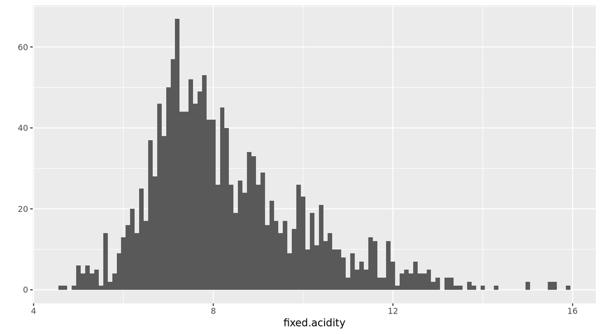

```
##    Min. 1st Qu.  Median    Mean 3rd Qu.    Max.
##    4.60    7.10    7.90    8.32    9.20   15.90
```

Fixed Acidity has a long tail

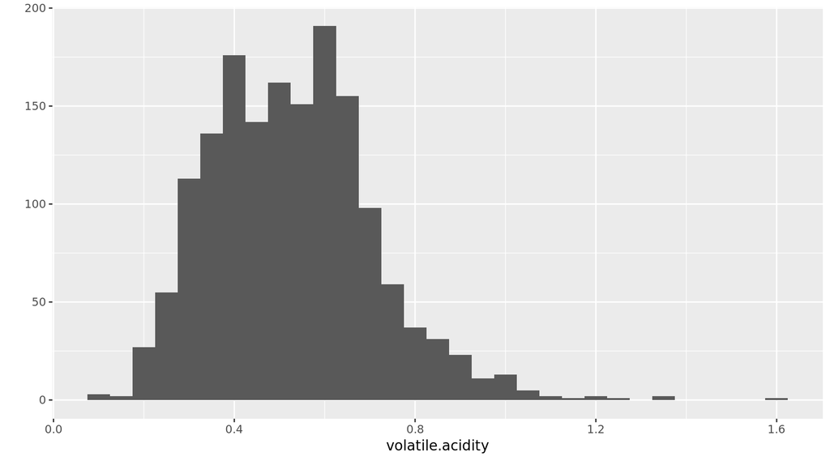

```
##    Min. 1st Qu.  Median    Mean 3rd Qu.    Max.
##  0.1200  0.3900  0.5200  0.5278  0.6400  1.5800
```

I wonder what accounts for the outlyer at 1.6

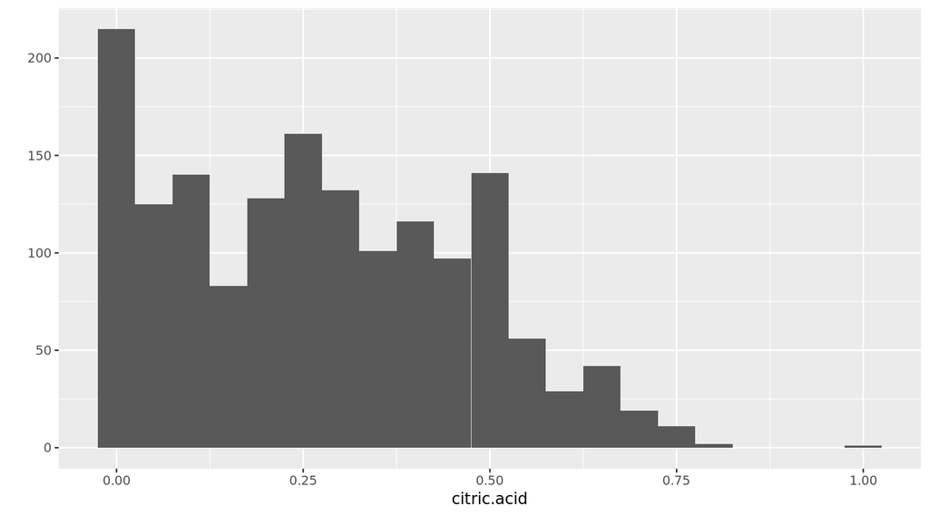

```
##    Min. 1st Qu.  Median    Mean 3rd Qu.    Max.
##   0.000   0.090   0.260   0.271   0.420   1.000
```

Volatile acidity and citrus acid are both under 1 gram not including outliers. I wonder how much the acidity effect quality.

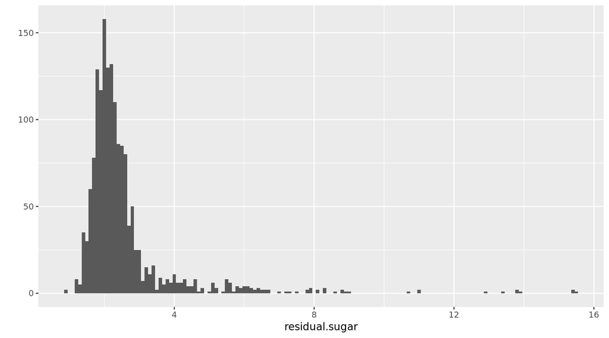

```
##    Min. 1st Qu.  Median    Mean 3rd Qu.    Max.
##   0.900   1.900   2.200   2.539   2.600  15.500
```

There is a lot of outliers for sugar. 50% is between 1.90 grams and 2.6 grams. The max is around 15 and a nice little bump is around 4 grams on the chart.

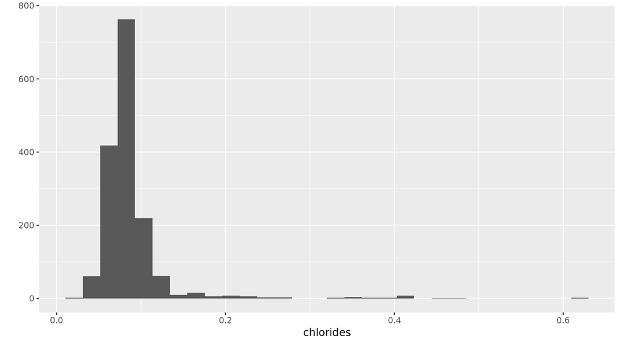

```
##    Min. 1st Qu.  Median    Mean 3rd Qu.    Max.
## 0.01200 0.07000 0.07900 0.08747 0.09000 0.61100
```

Most of the salt content is around the same amount. Besides the outliers I don’t think the chlorides will affect much.

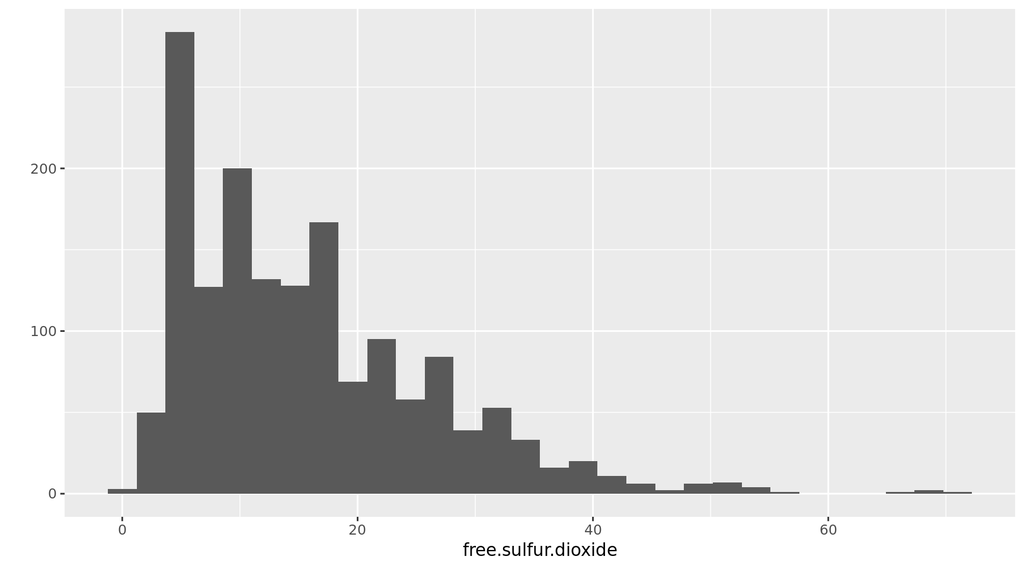

```
##    Min. 1st Qu.  Median    Mean 3rd Qu.    Max.
##    1.00    7.00   14.00   15.87   21.00   72.00
```

The Small hump out around 50 is intersting

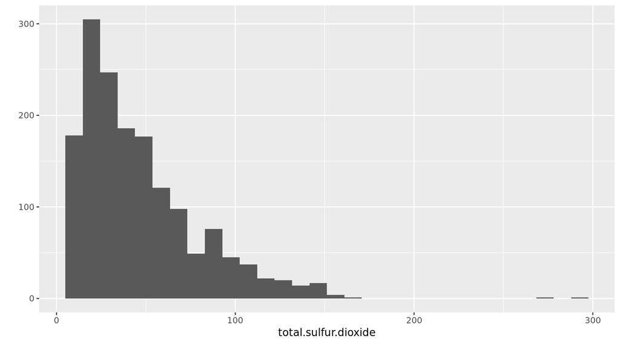

[output not shown]

Sulfur seems to have a lot of outliers. Once again I wonder how this affects quality.

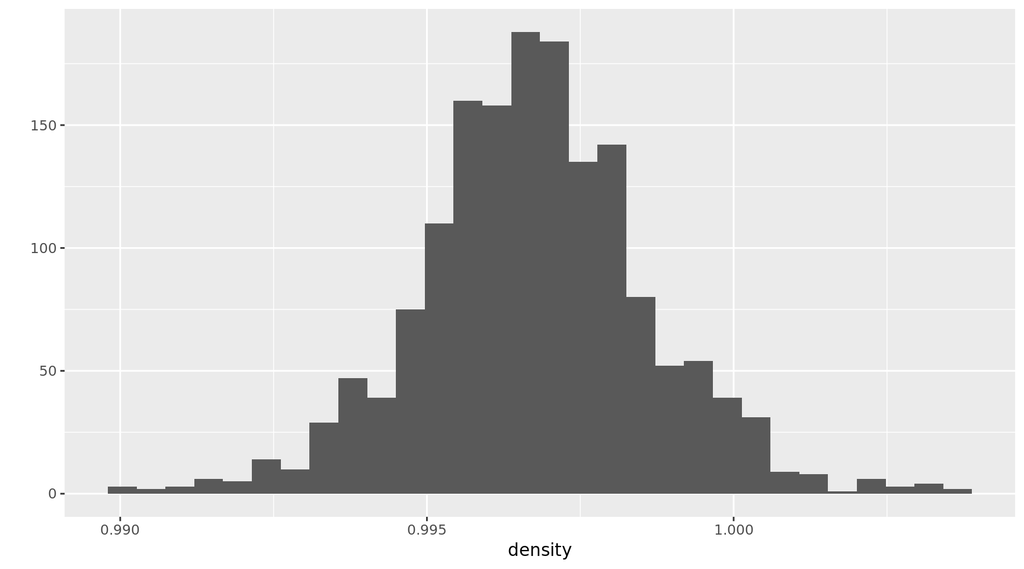

```
##    Min. 1st Qu.  Median    Mean 3rd Qu.    Max.
##  0.9901  0.9956  0.9968  0.9967  0.9978  1.0037
```

Density seems like a standard distorbution

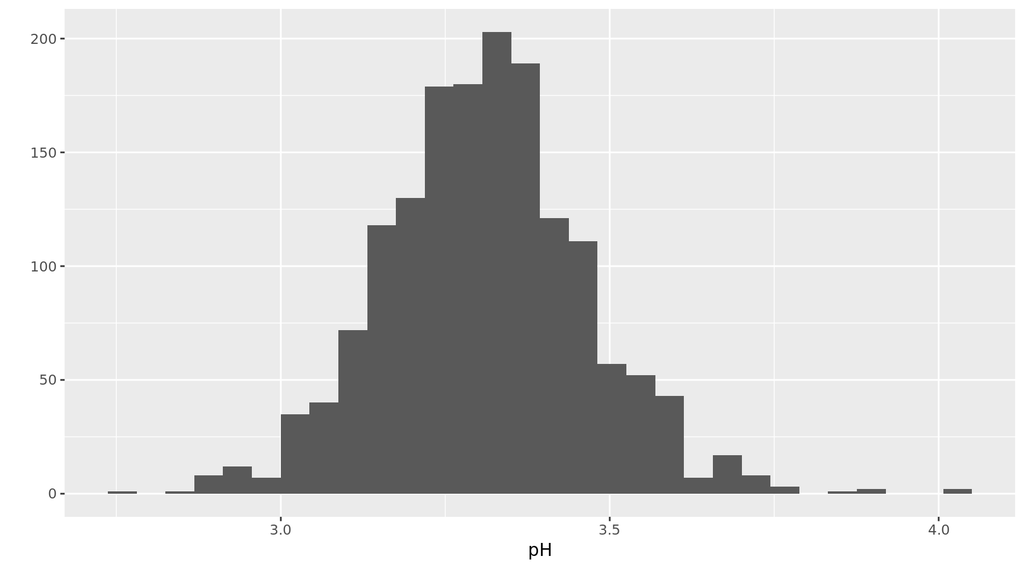

```
##    Min. 1st Qu.  Median    Mean 3rd Qu.    Max.
##   2.740   3.210   3.310   3.311   3.400   4.010
```

I wonder how high the correlation is for pH level and density are. Both have a low about of outliers and seem to match up pretty well.

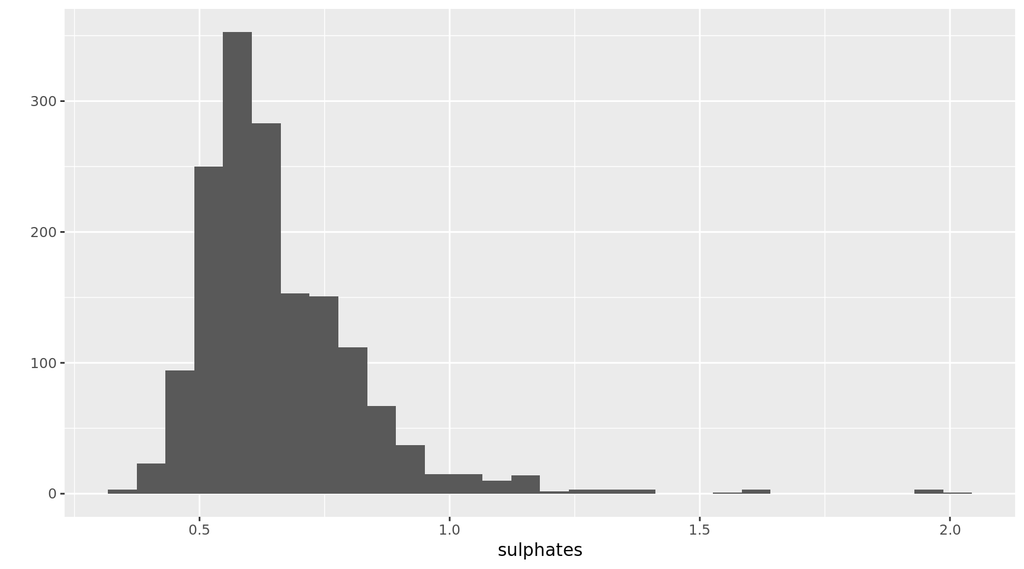

```
##    Min. 1st Qu.  Median    Mean 3rd Qu.    Max.
##  0.3300  0.5500  0.6200  0.6581  0.7300  2.0000
```

Quite a few outlyers for sulphates

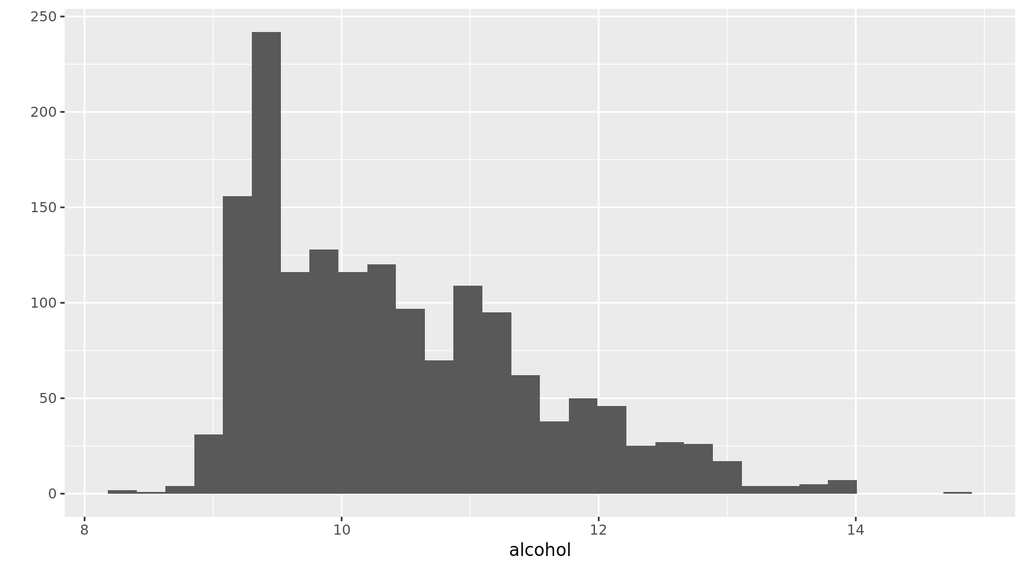

```
##    Min. 1st Qu.  Median    Mean 3rd Qu.    Max.
##    8.40    9.50   10.20   10.42   11.10   14.90
```

A long tail on alcohol

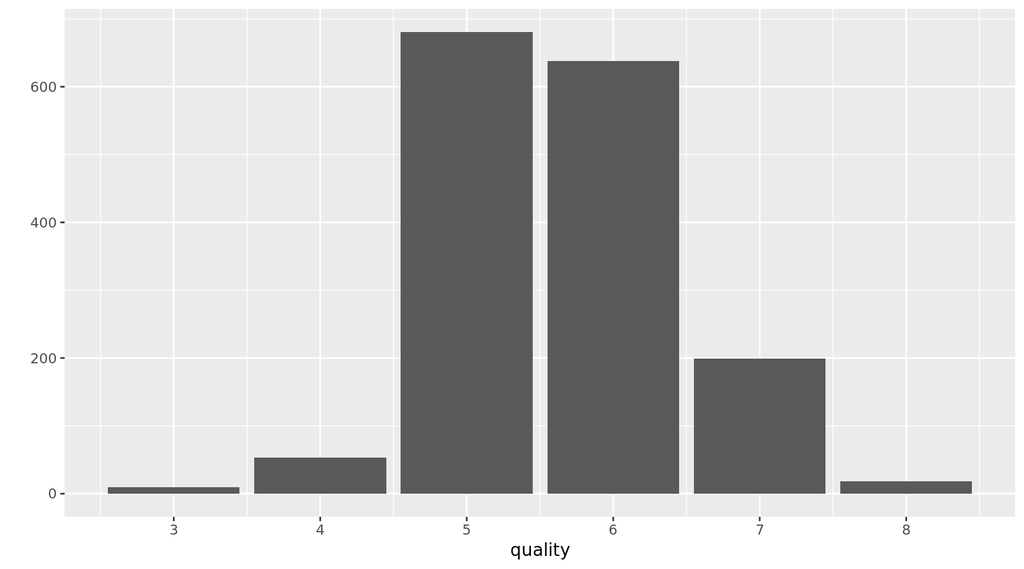

The quality goes from 0 to 10 but three is only results for 3 - 8

Our dataset has 13 variables with 1599 observations.

# Univariate Analysis

### What is the structure of your dataset?

There are 1599 red wines and 13 variables. All variables are measured in grams or milligrams except, pH (measured by the pH scale), alcohol(measured by volume), and quality(messured on a scale of 0 to 10).

### What is/are the main feature(s) of interest in your dataset?

The main features are quality and alcohol. I would like to know how the other features have the most effect on quality.

### What other features in the dataset do you think will help support your \ investigation into your feature(s) of interest?

pH, alcohol, and sugar. These are three features that are easy to taste. I thinking these will have a huge effect on the quality.

### Did you create any new variables from existing variables in the dataset?

No I did not create any new variables.

### Of the features you investigated, were there any unusual distributions? \ Did you perform any operations on the data to tidy, adjust, or change the form \ of the data? If so, why did you do this?

Some of the wines have a very large amount of sugar. But at around 15 grams its way lower than the 45 grams that is labeled as sweet wine in the document about the dataset.

# Bivariate Plots Section

```
##                          X fixed.acidity volatile.acidity citric.acid
## X                     1.00         -0.27            -0.01       -0.15
## fixed.acidity        -0.27          1.00            -0.26        0.67
## volatile.acidity     -0.01         -0.26             1.00       -0.55
## citric.acid          -0.15          0.67            -0.55        1.00
## residual.sugar       -0.03          0.11             0.00        0.14
## chlorides            -0.12          0.09             0.06        0.20
## free.sulfur.dioxide   0.09         -0.15            -0.01       -0.06
## total.sulfur.dioxide -0.12         -0.11             0.08        0.04
## density              -0.37          0.67             0.02        0.36
## pH                    0.14         -0.68             0.23       -0.54
## sulphates            -0.13          0.18            -0.26        0.31
## alcohol               0.25         -0.06            -0.20        0.11
## quality               0.07          0.12            -0.39        0.23
##                      residual.sugar chlorides free.sulfur.dioxide
## X                             -0.03     -0.12                0.09
## fixed.acidity                  0.11      0.09               -0.15
## volatile.acidity               0.00      0.06               -0.01
## citric.acid                    0.14      0.20               -0.06
## residual.sugar                 1.00      0.06                0.19
## chlorides                      0.06      1.00                0.01
## free.sulfur.dioxide            0.19      0.01                1.00
## total.sulfur.dioxide           0.20      0.05                0.67
## density                        0.36      0.20               -0.02
## pH                            -0.09     -0.27                0.07
## sulphates                      0.01      0.37                0.05
## alcohol                        0.04     -0.22               -0.07
## quality                        0.01     -0.13               -0.05
##                      total.sulfur.dioxide density    pH sulphates alcohol
## X                                   -0.12   -0.37  0.14     -0.13    0.25
## fixed.acidity                       -0.11    0.67 -0.68      0.18   -0.06
## volatile.acidity                     0.08    0.02  0.23     -0.26   -0.20
## citric.acid                          0.04    0.36 -0.54      0.31    0.11
## residual.sugar                       0.20    0.36 -0.09      0.01    0.04
## chlorides                            0.05    0.20 -0.27      0.37   -0.22
## free.sulfur.dioxide                  0.67   -0.02  0.07      0.05   -0.07
## total.sulfur.dioxide                 1.00    0.07 -0.07      0.04   -0.21
## density                              0.07    1.00 -0.34      0.15   -0.50
## pH                                  -0.07   -0.34  1.00     -0.20    0.21
## sulphates                            0.04    0.15 -0.20      1.00    0.09
## alcohol                             -0.21   -0.50  0.21      0.09    1.00
## quality                             -0.19   -0.17 -0.06      0.25    0.48
##                      quality
## X                       0.07
## fixed.acidity           0.12
## volatile.acidity       -0.39
## citric.acid             0.23
## residual.sugar          0.01
## chlorides              -0.13
## free.sulfur.dioxide    -0.05
## total.sulfur.dioxide   -0.19
## density                -0.17
## pH                     -0.06
## sulphates               0.25
## alcohol                 0.48
## quality                 1.00
```

Alcohol has the largest correlation with quality.I would like to so how.

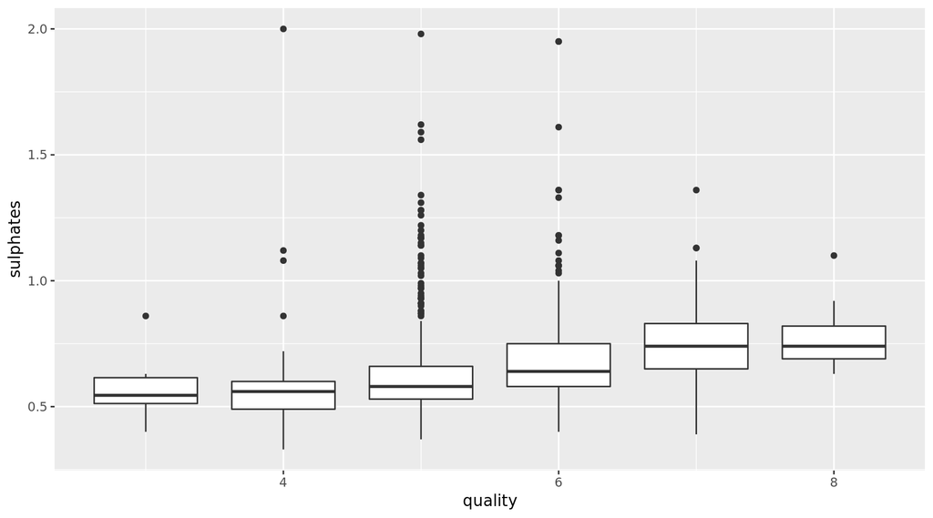

The level of suphates seems to have some effect on quality

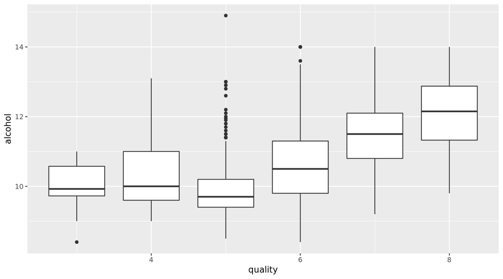

Why is the mean the lowest for a quality level of 5 yet has the highest outlier? The trend seems to be more alcohol higher quality, but 5 breaks that.

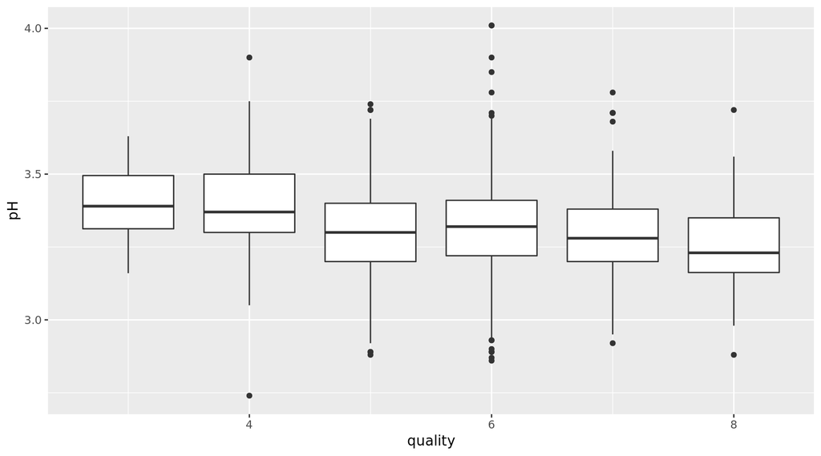

pH levels seem to have a low correlation with slight low pH levels being a higher quality

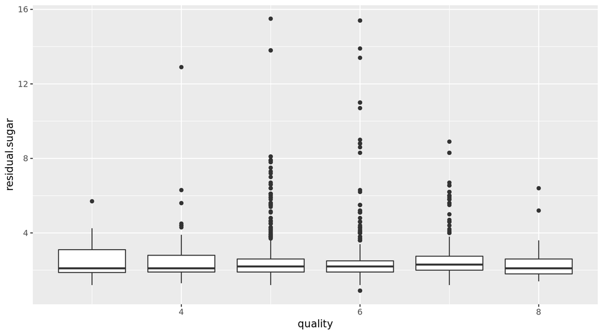

Residual sugar seems to have little or no effect on the level of quality of the wine.

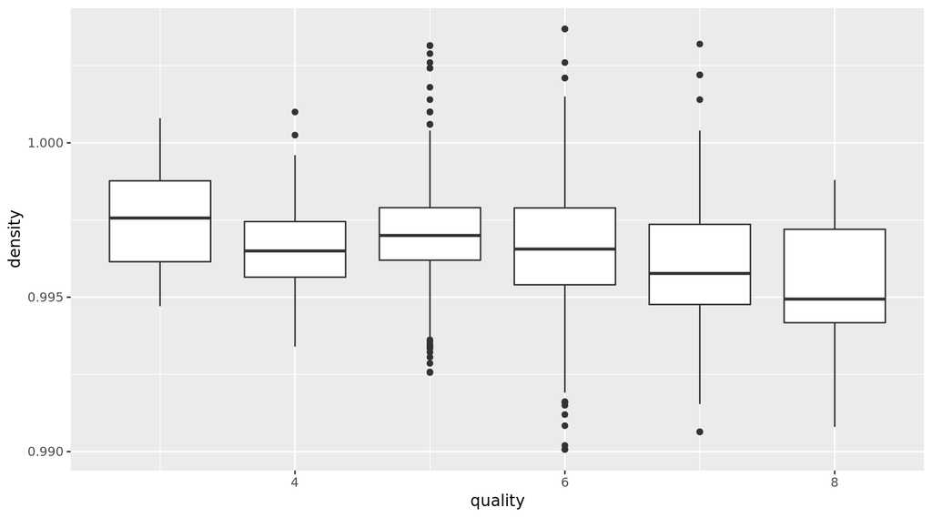

With all the outlyers at 5 and 6 I wonder if peopple just picked the numbers for no good reason.

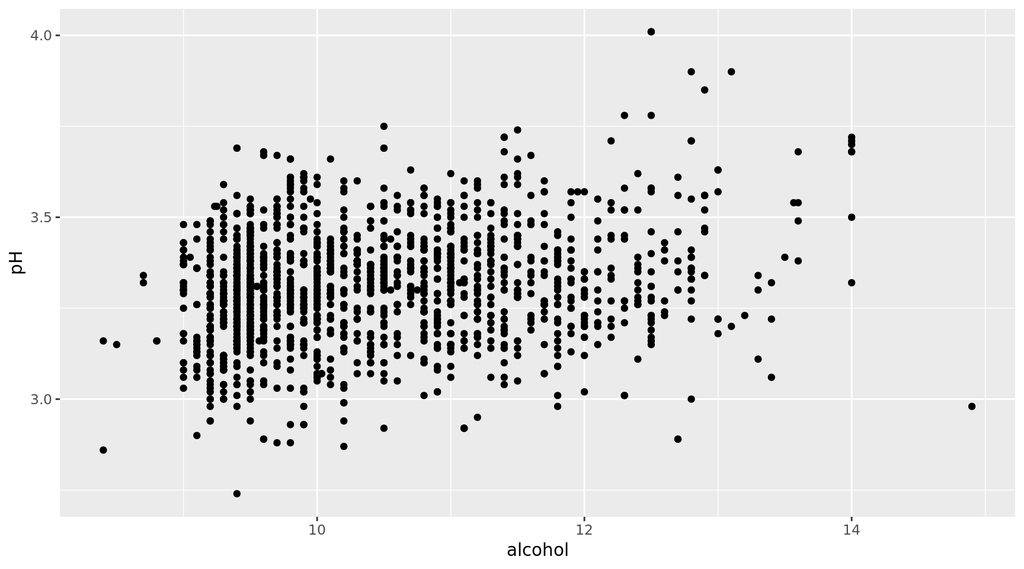

Not suprising, alcohol is in a limited area of the pH scale

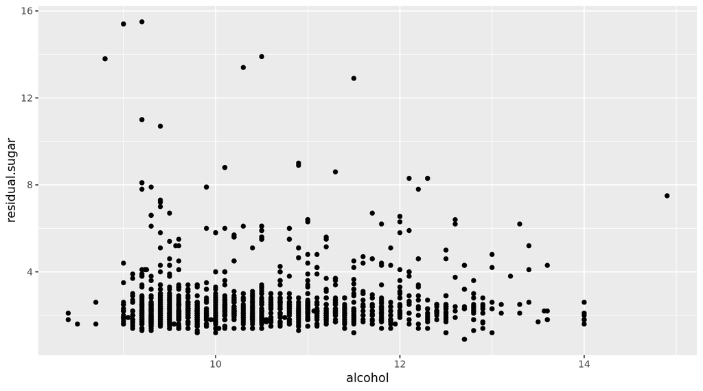

Not knowing much about wine I would have though that sugar had some afect on alcohol levels

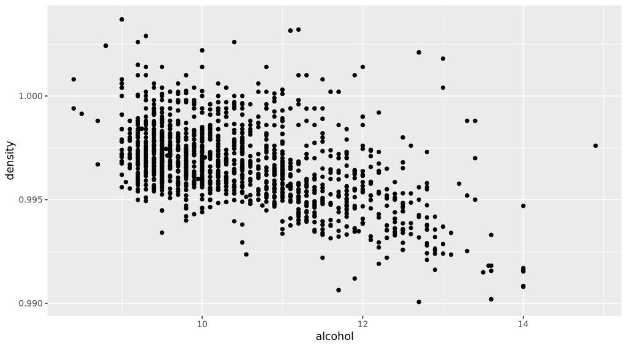

Alcohol has a negative correlation with density.

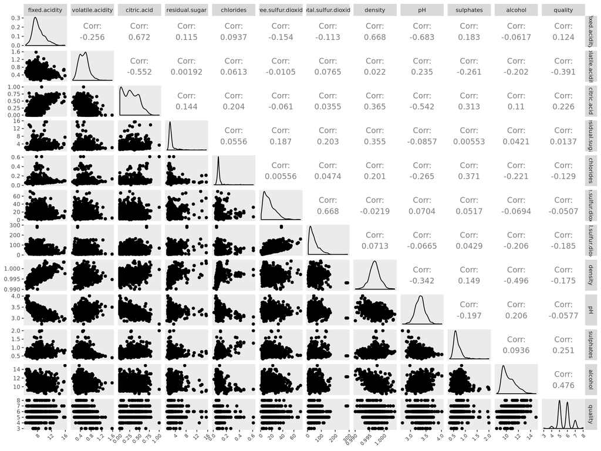

A good overview of the bivariate plots.

# Bivariate Analysis

### Talk about some of the relationships you observed in this part of the \ investigation. How did the feature(s) of interest vary with other features in \ the dataset?

It seems that most of the data that I though would have a correlation did not. This may be due to my lack of knowable of wine. I thought the sugar level and alcohol levels would have a higher coloration. I am also surprised that sugar didn’t have much effect on the rated level of quality. I thought there would be some bias in personal taste but it does not make much of a difference.

### Did you observe any interesting relationships between the other features \ (not the main feature(s) of interest)?

Overall sugar seems to have a low or no correlation with anything.

# Multivariate Plots Section

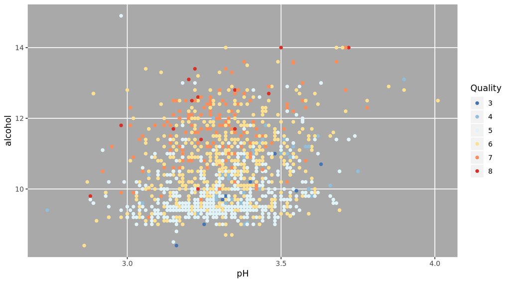

Alcohol seems to have the most affect on quality

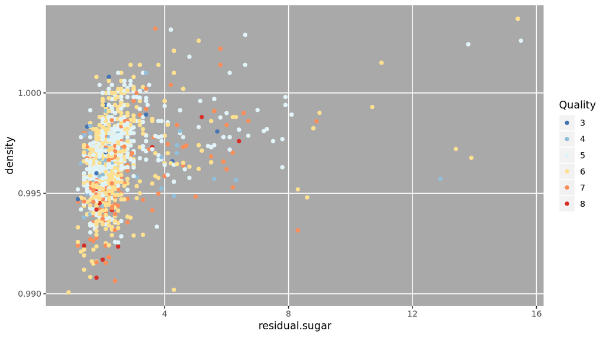

Density and sugar don’t seem to efect quality

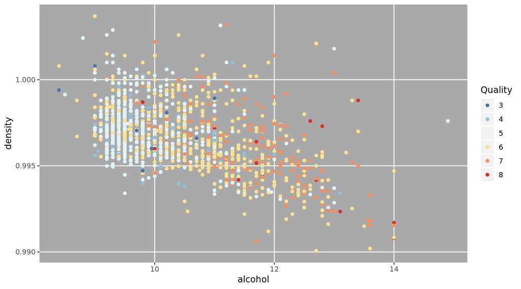

Less density looks to mean more alcohol and higher quality

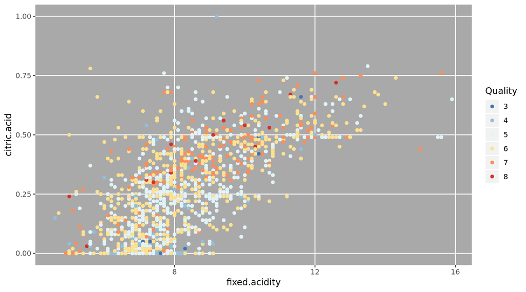

A grouping is around zero citric acid

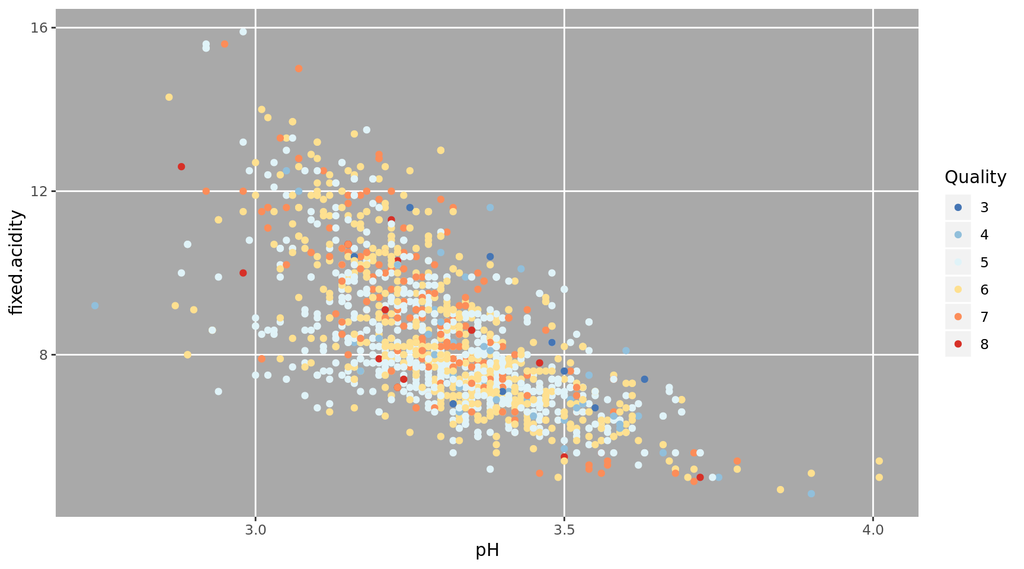

Under a pH level of 3 the fixed acidity have a wide range. Over 3 and a linear progression shows.

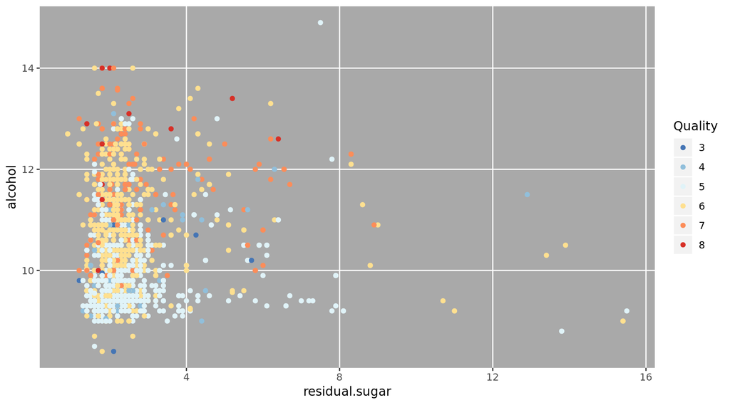

Most of the far outlyers are of quality 6

# Multivariate Analysis

### Talk about some of the relationships you observed in this part of the \ investigation. Were there features that strengthened each other in terms of \ looking at your feature(s) of interest?

Quality seems to only have a high correlation with alcohol levels.

### Were there any interesting or surprising interactions between features?

No

strengths and limitations of your model.

# Final Plots and Summary

### Plot One

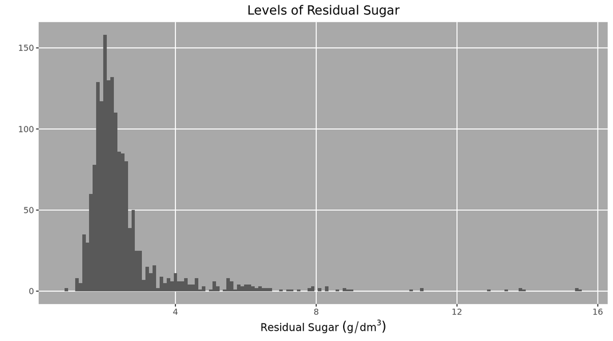

### Description One

Most of the Sugar Residual is around 2.5 grams. But it is interesting of how large the outliers get. With a max of about 15 grams.

### Plot Two

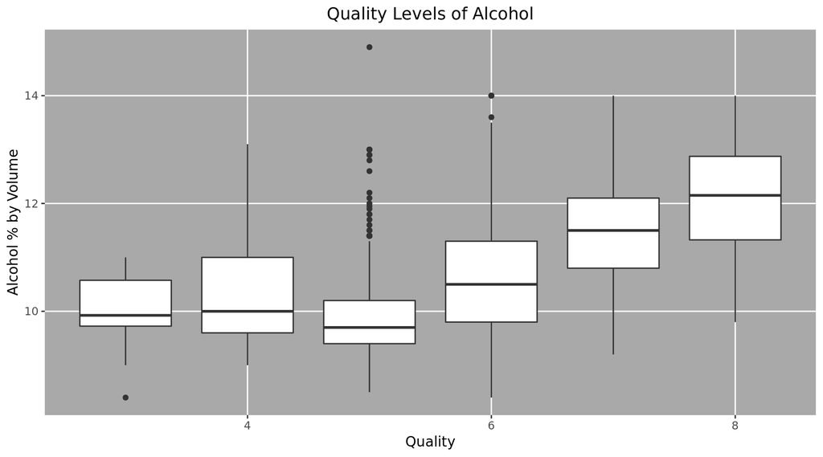

### Description Two

This graph shows the levels of alcohol by quality. Most of the outliers is around which is the middle of the 0 - 10 scale. Besides five, as the quality increased so does the alcohol level.

### Plot Three

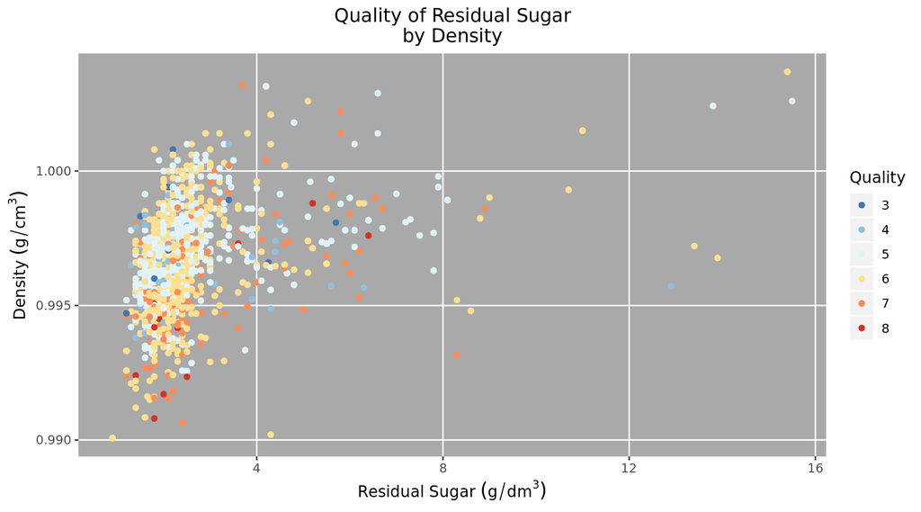

### Description Three

This graph details the quality of residual sugar by density. Residual sugar and density have little effect on the quality.

# Reflection

This was my first deep dive into R and I love it. R seems great for working with data that needs to be shown off. I had to think more about how the information will look then I had to before taking this course. Rstudio also makes working with R easy with it’s tab complection and help function. Over all I’m glad I learn this and plan to use R in future projects.

One thing I would like to expand on is why quality has so many 5 and 6. Was there a wide range of quality perefernces or did most people pick 5 or 6. I’ll have to look at the data set used to make the quality value.